# PCAs

# Introducción

El analisis de componentes principales o PCA por sus siglas en ingles es un metodo de reduccion de dimensionalisas que comunmente se usa para reducir la dimensionalidad de grandes sets de datos transformandos los mismos en datos simplicados que igual contengan la mayor cantidad de informacion posible del set original. Es uno de los métodos de análisis de datos multivariantes más utilizados que permite investigar conjuntos de datos multidimensionales con variables cuantitativas.

En palabras mas simples (y al nivel de estadistica en el que comprendo los PCAs) este analisis lo que hace es transformar tus datos en “distancias” que toman en cuenta todas tus variables independientes y las traduce a puntos en un plano. Los valores de las variables dependientes definen cuales puntos estaran mas cerca unos de otros en el plano y de ahi se puede determinar la relacion que existe entre tus muestras.

El resultado de los PCAs son coordenadas por lo que siempre vienen acompanados de un grafico en el cual los ejes no tienen ninguna unidad. Siempre se usan el PCA 1 y el 2 para graficar ya que estos son los que tienen el mayor porcentaje de explicacion en la variacion de los datos y ese porcentaje usualmente es lo que se reporta en el grafico.

# Calcular PCAs

```r
summary(PCAc) # Checar
```

```
Importance of components:
                          PC1    PC2     PC3     PC4
Standard deviation     5.0489 2.4236 1.47058 1.25544
Proportion of Variance 0.6536 0.1506 0.05545 0.04041
Cumulative Proportion  0.6536 0.8042 0.85968 0.90009
                           PC5     PC6     PC7     PC8
Standard deviation     1.10892 0.89462 0.68498 0.59706
Proportion of Variance 0.03153 0.02052 0.01203 0.00914
Cumulative Proportion  0.93162 0.95214 0.96417 0.97332
                           PC9    PC10    PC11    PC12
Standard deviation     0.52471 0.43547 0.41249 0.33539
Proportion of Variance 0.00706 0.00486 0.00436 0.00288
Cumulative Proportion  0.98037 0.98524 0.98960 0.99248
                         PC13    PC14    PC15   PC16
Standard deviation     0.2721 0.24780 0.22027 0.1873
Proportion of Variance 0.0019 0.00157 0.00124 0.0009
Cumulative Proportion  0.9944 0.99596 0.99720 0.9981
                          PC17    PC18    PC19    PC20
Standard deviation     0.18331 0.12157 0.10313 0.09250
Proportion of Variance 0.00086 0.00038 0.00027 0.00022
Cumulative Proportion  0.99896 0.99934 0.99961 0.99983
                          PC21    PC22     PC23     PC24
Standard deviation     0.07142 0.03709 0.006077 0.001736
Proportion of Variance 0.00013 0.00004 0.000000 0.000000
Cumulative Proportion  0.99996 1.00000 1.000000 1.000000
                            PC25
Standard deviation     3.519e-16
Proportion of Variance 0.000e+00
Cumulative Proportion  1.000e+00
```

Si se fijan al correr el resumen de este objeto dice que nos va a dar la importancia de los componentes. En este caso tenemos 25 PCAs o componentes ya que tenemos 25 muestras. Como mencione anteriormente los que usan a graficar es PC1 y 2 y para saber los porcentajes se toma la proporcion de varianza.

La proporcion de varianza se puede definir a el porcentaje que dicho PC describe los datos. Si entre el PC 1 y 2 el porcentaje o proporcion de varianza pasan el 50% quiere decir que son “significativas” y si se pueden usar para describir nuestros datos. En este caso:

- PC1: 65.36 %
- PC2: 15.06 %

# El gráfico

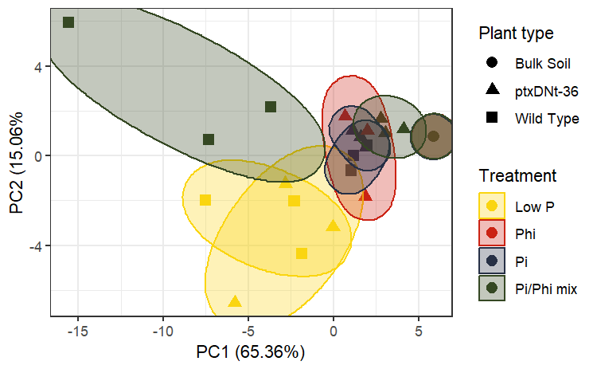